```python
!pip install datasets
!pip install --upgrade google-generativeai
```

```python
import pandas as pd
import numpy as np

from torch import nn
from torch.utils.data import Dataset, DataLoader
from tqdm.notebook import tqdm
from transformers import AutoTokenizer, AutoModelForSequenceClassification
from datasets import load_dataset
import torch
```

# HW 7: Generative AI

Large language models (LLMs), like ChatGPT and Gemini, have emerged as transformative tools in today's world. These sophisticated models are usually trained on diverse enormous datasets and tasks, which make them achieve the human-level capability on the trained task. Beyond the in-domain performances, LLMs demonstrate exceptional results in unseen data and tasks using only prompt engineering techniques. Prompt engineering involves designing the prompts that instruct the model to perform a specific task or influence a beneficial behavior without retraining the models. The low complexity of this approach makes it a preferable choice for everyday users or even researchers. Nevertheless, without fine-tuning the model, the prompt engineering performance is usually bounded. To grapple with this challenge, the other branches of approach introduce effective ways to fine-tune these colossal models. In this homework, you will learn how to implement these methods. We separate the homework into two sections: 1. Prompt Engineering and 2. Low-Rank Adapation (LoRA).

In the first section, we introduce prompt engineering methods, which do not involve optimizing the model but rather the prompts. It is the easiest method and something that everyone is doing now. In prompt engineering, the prompts are specifically designed to instruct the model to perform a specific task, influencing their behavior.

The second section revolves around methods that optimize the models or parameters. Specifically, you will learn what is Low-rank Adaptation (LoRA).

## Dataset Preparation

In this assignment, we use a subset of the IMDB review dataset. This dataset contains movie reviews and sentimental labels, determining whether the review is positive or negative. For more details about the dataset, please visit the [huggingface website](https://huggingface.co/datasets/stanfordnlp/imdb).

```python
dataset = load_dataset("stanfordnlp/imdb")

train_dataset = dataset["train"].shuffle(seed=42).select(range(1000))
test_dataset = dataset["test"].shuffle(seed=42).select(range(200))
```

To observe each datapoint, you can `for loop` through the `train_dataset`. Each datapoint contains text and labels as shown in the following cell.

```python
for dataset in train_dataset:
  print(f"Text:", dataset["text"])
  print(f"Label:", dataset["label"])
  break
```

```
Text: There is no relation at all between Fortier and Profiler but the fact that both are police series about violent crimes. Profiler looks crispy, Fortier looks classic. Profiler plots are quite simple. Fortier's plot are far more complicated... Fortier looks more like Prime Suspect, if we have to…
Label: 1
```

## Part 1: Prompt Engineering

In this part, you will learn two prompt engineering techniques 1. Chain-of-thought prompt (COT) 2. N-shot prompt. First, you need to create an API key and put it into Google Colab. Please follow the instructions below to complete this process.

### Create API Key

Go create an API key for using Gemini (FREE!) here, https://aistudio.google.com/app/apikey. Make sure the plan says "Free of charge"

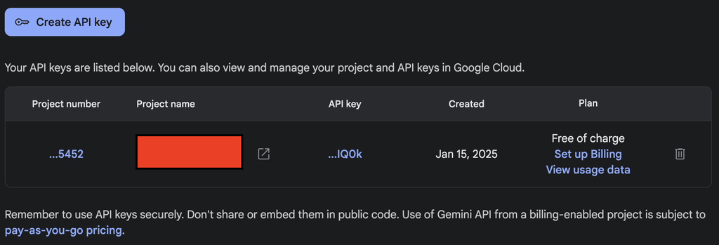

### Add API to notebook

After creating your API key, add it to your colab notebook.

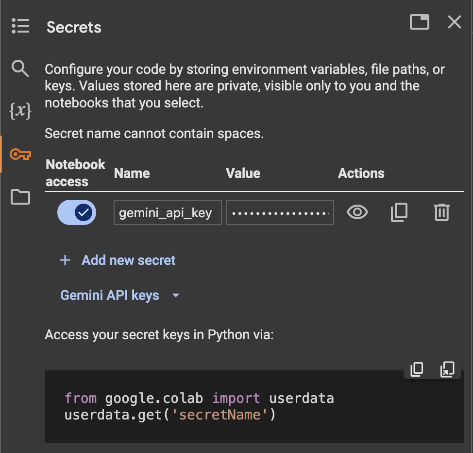

### Code

#### FYI: Free Tier Rate Limits

- For the `gemini-2.0-flash-lite`, you are allowed 30 requests/min and 1,500 requests/day
- For `gemini-2.0-flash-001` and `gemini-1.5-flash`, it is 15 requests per minute and 1,500RPD.

```python
from google.colab import userdata
api_key = userdata.get('gemini_api_key')
```

```python
import google.generativeai as genai
from tqdm import tqdm

genai.configure(api_key=api_key)
generation_config = genai.GenerationConfig(
        temperature=0,
)
model = genai.GenerativeModel("gemini-2.0-flash-001", generation_config=generation_config)
```

```python
from google.api_core import retry

# Catch transient Gemini errors.
def is_retryable(e) -> bool:
    if retry.if_transient_error(e):
        # Good practice, but probably won't fire with the google-genai SDK
        return True
    elif (isinstance(e, genai.errors.ClientError) and e.code == 429):
        # Catch 429 quota exceeded errors
        return True
    elif (isinstance(e, genai.errors.ServerError) and e.code == 503):
        # Catch 503 model overloaded errors
        return True
    else:
        return False

@retry.Retry(predicate=is_retryable)
def generate_content_with_rate_limit(prompt):
  return model.generate_content(prompt).text

# Here is am example how to use our code.
prompt = "What is the capital of Thailand?"
response = generate_content_with_rate_limit(prompt)
print(response)
```

```
The capital of Thailand is **Bangkok**.
```

### TODO 1: Create a prompt to instruct Gemini to give the number 1 if the given text is spam and the number 0 otherwise. Then, extract the answer for each datapoint and calculate the accuracy.

In general, we can simply tell the model to classify the SMS using this prompt `Please determine whether the given text SMS is spam or not. Give text: [Text]`. However, the structure of the response may be different for each datapoint, making it hard to extract the answer. Therefore, you should explicitly tell the model to give a binary output (**TODO 1.1**) and then extract the answer (**TODO 1.2**).

Note: You do not need to worry if the warning messages appear because of overuse. The implemented code handles this case and tries to send the prompt until it gets the responses.

```python
# TODO 1.1: Design your own prompt. Feel free to change this prompt.
prompt =  "You are a binary SMS spam classifier. Please classify the given SMS text as spam (1) or not spam (0). Respond with only a single digit: 1 for spam, 0 for not spam. Given text: [TEXT]"
predicted = []
labels = []

for data in tqdm(test_dataset, desc="Prompting"):
  filled_prompt = prompt.replace("[TEXT]", data["text"])
  response = generate_content_with_rate_limit(filled_prompt)
  # TODO 1.2: Extract the answer for each datapoint
  finalprediction = int(response) if response in ["0", "1"] else 0
  predicted.append(finalprediction)
  labels.append(data["label"])
```

You should achieve approximately 52.5% accuracy. With a simple prompt, LLMs struggle to perform well and need more advanced techniques, such as Chain-of-thought or N-shot prompting.

```python
predicted = np.array(predicted)
labels = np.array(labels)
accuracy = (predicted == labels).mean()
print(f"Accuracy: {accuracy}")
```

```
Accuracy: 0.52
```

### TODO 2: Use the Chain-of-thought technique to induce the reasoning in the model. Add the phrase 'Think step by step' to your prompt.

When asked to answer a question, humans usually perform a reasoning step or decompose the intricate question into multiple trivial questions. Motivated by the human brain, the chain-of-thought prompt mimics human reasoning and directly instructs LLMs to derive the answers through reasoning using phrases like `Think step by step` or `Let's think about this problem carefully`. Furthermore, you can give more details to the prompt to give hints or intrinsic characteristics of a spam SMS; for example, too-good-to-be-true claims are often mentioned in a spam SMS.

**Suggestion**: You should instruct the model to answer in a format that is easy to extract the answer.

```python
# TODO 2.1: Design your own prompt. Feel free to change this prompt.
prompt = """You are a binary SMS spam classifier. Analyze the following SMS and determine if it is spam.

Think step by step:
1. Check for too-good-to-be-true claims.
2. Look for suspicious links or requests for personal information.
3. Identify excessive urgency or misleading language.
4. Determine whether the message is genuinely useful or deceptive.

After reasoning, **reply only with '1' if spam, or '0' if not spam'**.

Given text: [TEXT]"""


predicted = []
labels = []

for data in tqdm(test_dataset, desc="Prompting"):
    filled_prompt = prompt.replace("[TEXT]", data["text"])
    response = generate_content_with_rate_limit(filled_prompt).strip()

    # Ensure response is strictly 1 or 0
    finalprediction = int(response) if response in ["0", "1"] else 0  # Default to 0 if unexpected output

    predicted.append(finalprediction)
    labels.append(data["label"])
```

You should achieve approximately 52% accuracy. Even though we influence the model to use reasoning, it may still be too hard for them to classify the spam SMS without explicitly telling the pattern.

```python
predicted = np.array(predicted)
labels = np.array(labels)
accuracy = (predicted == labels).mean()
print(f"Accuracy: {accuracy}")
```

```
Accuracy: 0.52
```

### TODO 3: Add training datapoints into the prompt to let the model implicitly learn from our examples.

Large language models (LLMs) are often too big to train on a single GPU, preventing users who lack computational resources from fine-tuning them. To deal with this issue, everyday users can employ N-short prompting to perform in-context learning where the model derives the responses from the given examples. Here is an example of 1-shot learning:

```
Please determine whether the given text SMS is spam or not. If it is spam then you should only give the number 1, otherwise 0 at the end of your response.

Examples
Given text: There is no relation at all between Fortier and Profiler but the fact that both are police series about violent crimes. Profiler looks crispy, Fortier looks classic. Profiler plots are quite simple. Fortier's plot are far more complicated... Fortier looks more like Prime Suspect, if we have to spot similarities... The main character is weak and weirdo, but have "clairvoyance". People like to compare, to judge, to evaluate. How about just enjoying? Funny thing too, people writing Fortier looks American but, on the other hand, arguing they prefer American series (!!!). Maybe it's the language, or the spirit, but I think this series is more English than American. By the way, the actors are really good and funny. The acting is not superficial at all...
Answer: 1

Given text: In the process of trying to establish the audiences' empathy with Jake Roedel (Tobey Maguire) the filmmakers slander the North and the Jayhawkers. Missouri never withdrew from the Union and the Union Army was not an invading force. The Southerners fought for State's Rights: the right to own slaves, elect crooked legislatures and judges, and employ a political spoils system. There's nothing noble in that. The Missourians could have easily traveled east and joined the Confederate Army.<br /><br />It seems to me that the story has nothing to do with ambiguity. When Jake leaves the Bushwhackers, it's not because he saw error in his way, he certainly doesn't give himself over to the virtue of the cause of abolition.
Answer:
```

where 1 examples are given in the prompt and the test data point is appended at the end of the text. In this assignment (**TODO 3.1**), you must add 200 examples drawing from training data to the prompt.

```python
prompt = """Please determine whether the given text SMS is spam or not. If it is spam then you should only give the number 1, otherwise 0 at the end of your response.

Examples
[200_EXAMPLES]

Given text: [TEST_DATA]
Answer: """
predicted = []
labels = []

def n_examples(train_dataset, N):
    n_shot_examples = []

    for data in train_dataset.select(range(N)):
        n_shot_examples.append(f"Given text: {data['text']}")
        n_shot_examples.append(f"Answer: {data['label']}")
        n_shot_examples.append("\n")

    n_shot_examples = "\n".join(n_shot_examples)
    return n_shot_examples


n_shot_prompt = n_examples(train_dataset, 200)
prompt = prompt.replace("[200_EXAMPLES]", n_shot_prompt)


for data in tqdm(test_dataset, desc="Prompting"):
    filled_prompt = prompt.replace("[TEST_DATA]", data["text"])
    response = generate_content_with_rate_limit(filled_prompt).strip()

    # Ensure response is strictly 1 or 0
    finalprediction = int(response) if response in ["0", "1"] else 0  # Default to 0 if unexpected output

    predicted.append(finalprediction)
    labels.append(data["label"])
```

With N-shot prompting, you should achieve approximately 92.0% accuracy.

```python
predicted = np.array(predicted)
labels = np.array(labels)
accuracy = (predicted == labels).mean()
print(f"Accuracy: {accuracy}")
```

```
Accuracy: 0.915
```

## Part 2: Low-rank Adapation (LoRA)

With the discovery of scaling properties in deep learning models, several researchers tend to increase model size to achieve emergent properties, especially in the natural language processing (NLP) field. For example, GPT-3 contains 175 billion parameters, making it nearly impossible to fine-tune on limited resources. This trend prevents students like us from adapting these enormous foundation models on a single GPU (or with small resources).

To alleviate this problem, researchers have developed new fine-tuning methods, known as parameter-efficient transfer learning, which allow us to train large models with limited resources. The benefits of these methods extend not only to the training process but also to deployment. After fine-tuning, we only need to save a small number of parameters (the LoRA weights), enabling us to deploy the foundation model to various downstream tasks using minimal storage. One of the prevailing methods is Low Rank Adaptation (LoRA).

Another popular option is prompt tuning, where we only train special tokens that are prepended to the input. However, this is not the focus of this homework.

In this section, we will introduce traditional fine-tuning and LoRA.

#### Data Preparation

```python
class IMDbPromptTuningDataset(Dataset):
    def __init__(self, dataset, tokenizer, max_length=512):
        self.dataset = dataset
        self.tokenizer = tokenizer
        self.max_length = max_length

    def __len__(self):
        return len(self.dataset)

    def __getitem__(self, idx):
        text = self.dataset[idx]["text"]
        label = self.dataset[idx]["label"]

        encoding = self.tokenizer(
            text,
            truncation=True,
            padding="max_length",
            max_length=self.max_length,
            return_tensors="pt"
        )

        return {
            "input_ids": encoding["input_ids"].squeeze(),
            "attention_mask": encoding["attention_mask"].squeeze(),
            "labels": torch.tensor(label, dtype=torch.long)
        }
```

```python
# Load tokenizer and Model
tokenizer = AutoTokenizer.from_pretrained("distilbert-base-uncased")
model = AutoModelForSequenceClassification.from_pretrained("distilbert-base-uncased", num_labels=2)

# Initialize Dataset
batch_size = 16
imdb_train = IMDbPromptTuningDataset(train_dataset, tokenizer, max_length=model.config.max_position_embeddings)
train_loader = DataLoader(imdb_train, batch_size=batch_size, shuffle=True)

imdb_test = IMDbPromptTuningDataset(test_dataset, tokenizer, max_length=model.config.max_position_embeddings)
test_loader = DataLoader(imdb_test, batch_size=batch_size, shuffle=False)
```

```
Some weights of DistilBertForSequenceClassification were not initialized from the model checkpoint at distilbert-base-uncased and are newly initialized: ['classifier.bias', 'classifier.weight', 'pre_classifier.bias', 'pre_classifier.weight']
You should probably TRAIN this model on a down-stream task to be able to use it for predictions and inference.
```

## Traditional Fine tuning

In the traditional fine-tuning method, the entire model is trained, which is computationally expensive. An alternative approach is to fine-tune only certain layers of the model to reduce resource usage while still adapting the model to a specific task.

To keep the implementation simple, you are assigned to train only the query weights (`q_lin`) in the self-attention layers.

The code below displays the names of all layers in the DistilBert. This will help you identify which layers to freeze or train.

```python
model = AutoModelForSequenceClassification.from_pretrained("distilbert-base-uncased", num_labels=2)
for name, module in model.named_modules():
  print(name, type(module))
```

```
Some weights of DistilBertForSequenceClassification were not initialized from the model checkpoint at distilbert-base-uncased and are newly initialized: ['classifier.bias', 'classifier.weight', 'pre_classifier.bias', 'pre_classifier.weight']
You should probably TRAIN this model on a down-stream task to be able to use it for predictions and inference.
```

```
 <class 'transformers.models.distilbert.modeling_distilbert.DistilBertForSequenceClassification'>
distilbert <class 'transformers.models.distilbert.modeling_distilbert.DistilBertModel'>
distilbert.embeddings <class 'transformers.models.distilbert.modeling_distilbert.Embeddings'>
distilbert.embeddings.word_embeddings <class 'torch.nn.modules.sparse.Embedding'>
distilbert.embeddings.position_embeddings <class 'torch.nn.modules.sparse.Embedding'>
distilbert.embeddings.LayerNorm <class 'torch.nn.modules.normalization.LayerNorm'>
distilbert.embeddings.dropout <class 'torch.nn.modules.dropout.Dropout'>
distilbert.transformer <class 'transformers.models.distilbert.modeling_distilbert.Transformer'>
distilbert.transformer.layer <class 'torch.nn.modules.container.ModuleList'>
distilbert.transformer.layer.0 <class 'transformers.models.distilbert.modeling_distilbert.TransformerBlock'>
distilbert.transformer.layer.0.attention <class 'transformers.models.distilbert.modeling_distilbert.DistilBertSdpaAttention'>
distilbert.transformer.layer.0.attention.dropout <class 'torch.nn.modules.dropout.Dropout'>
distilbert.transformer.layer.0.attention.q_lin <class 'torch.nn.modules.linear.Linear'>
distilbert.transformer.layer.0.attention.k_lin <class 'torch.nn.modules.linear.Linear'>
distilbert.transformer.layer.0.attention.v_lin <class 'torch.nn.modules.linear.Linear'>
distilbert.transformer.layer.0.attention.out_lin <class 'torch.nn.modules.linear.Linear'>
distilbert.transformer.layer.0.sa_layer_norm <class 'torch.nn.modules.normalization.LayerNorm'>
distilbert.transformer.layer.0.ffn <class 'transformers.models.distilbert.modeling_distilbert.FFN'>
distilbert.transformer.layer.0.ffn.dropout <class 'torch.nn.modules.dropout.Dropout'>
distilbert.transformer.layer.0.ffn.lin1 <class 'torch.nn.modules.linear.Linear'>
distilbert.transformer.layer.0.ffn.lin2 <class 'torch.nn.modules.linear.Linear'>
distilbert.transformer.layer.0.ffn.activation <class 'transformers.activations.GELUActivation'>
distilbert.transformer.layer.0.output_layer_norm <class 'torch.nn.modules.normalization.LayerNorm'>
distilbert.transformer.layer.1 <class 'transformers.models.distilbert.modeling_distilbert.TransformerBlock'>
distilbert.transformer.layer.1.attention <class 'transformers.models.distilbert.modeling_distilbert.DistilBertSdpaAttention'>
distilbert.transformer.layer.1.attention.dropout <class 'torch.nn.modules.dropout.Dropout'>
distilbert.transformer.layer.1.attention.q_lin <class 'torch.nn.modules.linear.Linear'>
distilbert.transformer.layer.1.attention.k_lin <class 'torch.nn.modules.linear.Linear'>
distilbert.transformer.layer.1.attention.v_lin <class 'torch.nn.modules.linear.Linear'>
distilbert.transformer.layer.1.attention.out_lin <class 'torch.nn.modules.linear.Linear'>
distilbert.transformer.layer.1.sa_layer_norm <class 'torch.nn.modules.normalization.LayerNorm'>
distilbert.transformer.layer.1.ffn <class 'transformers.models.distilbert.modeling_distilbert.FFN'>
distilbert.transformer.layer.1.ffn.dropout <class 'torch.nn.modules.dropout.Dropout'>
distilbert.transformer.layer.1.ffn.lin1 <class 'torch.nn.modules.linear.Linear'>
distilbert.transformer.layer.1.ffn.lin2 <class 'torch.nn.modules.linear.Linear'>
distilbert.transformer.layer.1.ffn.activation <class 'transformers.activations.GELUActivation'>
distilbert.transformer.layer.1.output_layer_norm <class 'torch.nn.modules.normalization.LayerNorm'>
distilbert.transformer.layer.2 <class 'transformers.models.distilbert.modeling_distilbert.TransformerBlock'>
distilbert.transformer.layer.2.attention <class 'transformers.models.distilbert.modeling_distilbert.DistilBertSdpaAttention'>
distilbert.transformer.layer.2.attention.dropout <class 'torch.nn.modules.dropout.Dropout'>
```

[output cut: 41 more lines]

```
distilbert.transformer.layer.5.attention.dropout <class 'torch.nn.modules.dropout.Dropout'>
distilbert.transformer.layer.5.attention.q_lin <class 'torch.nn.modules.linear.Linear'>
distilbert.transformer.layer.5.attention.k_lin <class 'torch.nn.modules.linear.Linear'>
distilbert.transformer.layer.5.attention.v_lin <class 'torch.nn.modules.linear.Linear'>
distilbert.transformer.layer.5.attention.out_lin <class 'torch.nn.modules.linear.Linear'>
distilbert.transformer.layer.5.sa_layer_norm <class 'torch.nn.modules.normalization.LayerNorm'>
distilbert.transformer.layer.5.ffn <class 'transformers.models.distilbert.modeling_distilbert.FFN'>
distilbert.transformer.layer.5.ffn.dropout <class 'torch.nn.modules.dropout.Dropout'>
distilbert.transformer.layer.5.ffn.lin1 <class 'torch.nn.modules.linear.Linear'>
distilbert.transformer.layer.5.ffn.lin2 <class 'torch.nn.modules.linear.Linear'>
distilbert.transformer.layer.5.ffn.activation <class 'transformers.activations.GELUActivation'>
distilbert.transformer.layer.5.output_layer_norm <class 'torch.nn.modules.normalization.LayerNorm'>
pre_classifier <class 'torch.nn.modules.linear.Linear'>
classifier <class 'torch.nn.modules.linear.Linear'>
dropout <class 'torch.nn.modules.dropout.Dropout'>
```

### TODO 4: Freeze the Model and Train Only Attention Weights

You are assigned to freeze the entire model, except for the query attention weights (`q_lin`) and the classification and pre-classification head.

```python
for name, param in model.named_parameters():
    if "q_lin" in name or "classifier" in name or "pre_classifier" in name:
        param.requires_grad = True  # Allow tuning these layers
    else:
        param.requires_grad = False  # Freeze everything else
```

**Check Your Answer:** The number of learnable parameters is around 4135682.

```python
pytorch_total_params = sum(p.numel() for p in model.parameters() if p.requires_grad)
print(pytorch_total_params)
```

```
4135682
```

### Train Model

```python
optimizer = torch.optim.AdamW(model.parameters(), lr=5e-5)

device = torch.device("cuda" if torch.cuda.is_available() else "cpu")
print("Device:", device)
model.to(device)

num_epochs = 10
for epoch in tqdm(range(num_epochs)):
    model.train()
    for batch in tqdm(train_loader):
        input_ids = batch["input_ids"].to(device)
        attention_mask = batch["attention_mask"].to(device)
        labels = batch["labels"].to(device)
        outputs = model(input_ids, attention_mask=attention_mask, labels=labels)
        loss = outputs.loss
        loss.backward()
        optimizer.step()
        optimizer.zero_grad()

    model.eval()
    correct = 0
    total = 0
    with torch.no_grad():
        for batch in test_loader:
            input_ids = batch["input_ids"].to(device)
            attention_mask = batch["attention_mask"].to(device)
            labels = batch["labels"].to(device)
            outputs = model(input_ids, attention_mask=attention_mask)
            predictions = torch.argmax(outputs.logits, dim=-1)
            correct += (predictions == labels).sum().item()
            total += labels.size(0)

    accuracy = correct / total
    print(f"Epoch {epoch + 1}/{num_epochs} - Accuracy: {accuracy:.4f}")
```

[output not shown]

```
Device: cuda
```

## TODO 5-6: Initialize the LoRA Config and Set trainable parameters

Thanks to `peft` library, we can fine-tune the model with LoRA in two steps: 1. initialize the LoRAConfig and 2. set trainable parameters.

Your task is to initialize `LoRAConfig` and set rank (`r`) to 1 and lora alpha to 4. Apply LoRA only to the query weight in self-attention layers (`q_lin`). Ensure that you freeze the entire model, except for the LoRA weights, the bias in the LoRA-injected layers, and the classification and pre-classification head. You only need to make the classification and pre-classification heads trainable, while the rest of the parameters are already set according to our `LoRAConfig`. For more detail about `LoRAConfig`, please read the [documents](https://huggingface.co/docs/peft/en/package_reference/lora#:~:text=and%203.6..-,LoraConfig,-class%20peft.).

```python
from peft import LoraConfig, get_peft_model

# TODO 5: Initialize LoRAConfig
lora_config = LoraConfig(
    r=1,
    lora_alpha=4,
    target_modules=["q_lin"],
    bias="lora_only",
    lora_bias = True,
)

model = AutoModelForSequenceClassification.from_pretrained(
    "distilbert-base-uncased",
    num_labels=2
)
model = get_peft_model(model, lora_config)
model = model.to("cuda")

# TODO 6: Freeze everything except:
#   - LoRA weights (they come prefixed with "lora_")
#   - biases in the LoRA-injected layers
#   - classification head and pre-classification head
for name, param in model.named_parameters():
    # start by freezing all
    param.requires_grad = False

    # unfreeze any LoRA weights & their biases
    if "lora_" in name:
        param.requires_grad = True

# unfreeze the DistilBERT classification heads
for name, param in model.pre_classifier.named_parameters():
    param.requires_grad = True
for name, param in model.classifier.named_parameters():
    param.requires_grad = True

# sanity-check: print only those parameters that are trainable
for n, p in model.named_parameters():
    if p.requires_grad:
        print(n)
```

```
Some weights of DistilBertForSequenceClassification were not initialized from the model checkpoint at distilbert-base-uncased and are newly initialized: ['classifier.bias', 'classifier.weight', 'pre_classifier.bias', 'pre_classifier.weight']
You should probably TRAIN this model on a down-stream task to be able to use it for predictions and inference.
```

```
base_model.model.distilbert.transformer.layer.0.attention.q_lin.lora_A.default.weight
base_model.model.distilbert.transformer.layer.0.attention.q_lin.lora_B.default.weight
base_model.model.distilbert.transformer.layer.0.attention.q_lin.lora_B.default.bias
base_model.model.distilbert.transformer.layer.1.attention.q_lin.lora_A.default.weight
base_model.model.distilbert.transformer.layer.1.attention.q_lin.lora_B.default.weight
base_model.model.distilbert.transformer.layer.1.attention.q_lin.lora_B.default.bias
base_model.model.distilbert.transformer.layer.2.attention.q_lin.lora_A.default.weight
base_model.model.distilbert.transformer.layer.2.attention.q_lin.lora_B.default.weight
base_model.model.distilbert.transformer.layer.2.attention.q_lin.lora_B.default.bias
base_model.model.distilbert.transformer.layer.3.attention.q_lin.lora_A.default.weight
base_model.model.distilbert.transformer.layer.3.attention.q_lin.lora_B.default.weight
base_model.model.distilbert.transformer.layer.3.attention.q_lin.lora_B.default.bias
base_model.model.distilbert.transformer.layer.4.attention.q_lin.lora_A.default.weight
base_model.model.distilbert.transformer.layer.4.attention.q_lin.lora_B.default.weight
base_model.model.distilbert.transformer.layer.4.attention.q_lin.lora_B.default.bias
base_model.model.distilbert.transformer.layer.5.attention.q_lin.lora_A.default.weight
base_model.model.distilbert.transformer.layer.5.attention.q_lin.lora_B.default.weight
base_model.model.distilbert.transformer.layer.5.attention.q_lin.lora_B.default.bias
base_model.model.pre_classifier.weight
base_model.model.pre_classifier.bias
base_model.model.classifier.weight
base_model.model.classifier.bias
```

**Check Your Answer:** The number of learnable parameters is around 605954.

```python
pytorch_total_params = sum(p.numel() for p in model.parameters() if p.requires_grad)
print(pytorch_total_params)
```

```
605954
```

```python
optimizer = torch.optim.AdamW(model.parameters(), lr=5e-5)

device = torch.device("cuda" if torch.cuda.is_available() else "cpu")
print("Device:", device)
model.to(device)

num_epochs = 10
for epoch in tqdm(range(num_epochs)):
    model.train()
    for batch in tqdm(train_loader):
        input_ids = batch["input_ids"].to(device)
        attention_mask = batch["attention_mask"].to(device)
        labels = batch["labels"].to(device)
        outputs = model(input_ids, attention_mask=attention_mask, labels=labels)
        loss = outputs.loss
        loss.backward()
        optimizer.step()
        optimizer.zero_grad()

    model.eval()
    correct = 0
    total = 0
    with torch.no_grad():
        for batch in test_loader:
            input_ids = batch["input_ids"].to(device)
            attention_mask = batch["attention_mask"].to(device)
            labels = batch["labels"].to(device)
            outputs = model(input_ids, attention_mask=attention_mask)
            predictions = torch.argmax(outputs.logits, dim=-1)
            correct += (predictions == labels).sum().item()
            total += labels.size(0)

    accuracy = correct / total
    print(f"Epoch {epoch + 1}/{num_epochs} - Accuracy: {accuracy:.4f}")
```

[output not shown]

```
Device: cuda
```